# SI 370 - Homework #2: Data Visualization

### Q6 Create a bar plot that shows the number of tests conducted per 1000 people for each province in Canada.

How would you interpret the results of this bar plot given the results of bar plot in question 5.

```python
#first got the population and tests in two dfs and merged in order to make sure both were not cumulative
population = canada.groupby(['administrative_area_level_2']).agg({'population' : 'mean'})
tests = canada.groupby(['administrative_area_level_2']).max().reset_index()

result = pd.merge(population, tests, on="administrative_area_level_2")

result.head()
result['test_per_1000'] = (result.tests / result.population_x) * 1000
result.head()
```

|  | administrative_area_level_2 | population_x | id | date | vaccines | tests | confirmed | recovered | deaths | hosp | ... | administrative_area_level_1 | administrative_area_level_3 | latitude | longitude | key | key_google_mobility | key_apple_mobility | key_numeric | key_alpha_2 | test_per_1000 |
| --- | --- | --- | --- | --- | --- | --- | --- | --- | --- | --- | --- | --- | --- | --- | --- | --- | --- | --- | --- | --- | --- |
| 0 | Alberta | 4413146.0 | e61d6191 | 2021-09-22 | NaN | 5377503.0 | 285046.0 | 262148.0 | 2594.0 | NaN | ... | Canada | NaN | 53.9333 | -116.5765 | NaN | Alberta | Alberta | NaN | NaN | 1218.519170 |
| 1 | British Columbia | 5110917.0 | c229681f | 2021-09-22 | NaN | 3691352.0 | 180937.0 | 173215.0 | 1910.0 | NaN | ... | Canada | NaN | 49.2827 | -123.1207 | NaN | British Columbia | British Columbia | NaN | NaN | 722.248473 |
| 2 | Manitoba | 1377517.0 | 2a9fd65a | 2021-09-22 | NaN | 1023750.0 | 59880.0 | 58081.0 | 1207.0 | NaN | ... | Canada | NaN | 53.7609 | -98.8139 | NaN | Manitoba | Manitoba | NaN | NaN | 743.185021 |
| 3 | New Brunswick | 779993.0 | d177e539 | 2021-09-22 | NaN | 450681.0 | 3577.0 | 2970.0 | 49.0 | NaN | ... | Canada | NaN | 46.5653 | -66.4619 | NaN | New Brunswick | New Brunswick | NaN | NaN | 577.801339 |
| 4 | Newfoundland and Labrador | 521365.0 | d07806cb | 2021-09-22 | NaN | 341904.0 | 1609.0 | 1518.0 | 7.0 | NaN | ... | Canada | NaN | 53.1355 | -57.6604 | NaN | Newfoundland and Labrador | Newfoundland and Labrador | NaN | NaN | 655.786253 |

5 rows × 40 columns

```
matplotlib.axes._subplots.AxesSubplot
```

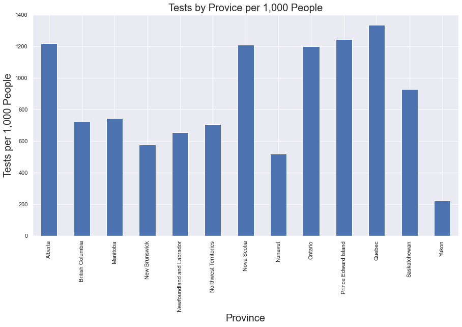

```python
result = result.set_index('administrative_area_level_2', drop=False)
f = result['test_per_1000'].plot(kind='bar')
plt.xlabel("Province",fontsize=20)
plt.ylabel("Tests per 1,000 People",fontsize=20)
plt.title('Tests by Provice per 1,000 People', fontsize=20)
type(f)
```

### Q7 Create a visualization that shows which Canadian province has the highest recovery rate.

Recovery rate is calculated as the number of recovered cases divided by the number of confirmed cases.

```python
#first got the recovery rate by dividing the recoved numbers by confirmed
province['recovery_rate'] = province['recovered'] / province['confirmed']
province.head()
```

| administrative_area_level_2 | id | date | vaccines | tests | confirmed | recovered | deaths | hosp | vent | icu | ... | administrative_area_level_1 | administrative_area_level_3 | latitude | longitude | key | key_google_mobility | key_apple_mobility | key_numeric | key_alpha_2 | recovery_rate |
| --- | --- | --- | --- | --- | --- | --- | --- | --- | --- | --- | --- | --- | --- | --- | --- | --- | --- | --- | --- | --- | --- |
| Yukon | 38791b01 | 2021-09-22 | NaN | 9129.0 | 725.0 | 693.0 | 9.0 | NaN | NaN | NaN | ... | Canada | NaN | 64.2823 | -135.0000 | NaN | Yukon | Yukon Territory | NaN | NaN | 0.955862 |
| Northwest Territories | eef40c88 | 2021-09-22 | NaN | 31701.0 | 834.0 | 594.0 | 2.0 | NaN | NaN | NaN | ... | Canada | NaN | 64.8255 | -124.8457 | NaN | Northwest Territories | Northwest Territories | NaN | NaN | 0.712230 |
| British Columbia | c229681f | 2021-09-22 | NaN | 3691352.0 | 180937.0 | 173215.0 | 1910.0 | NaN | NaN | NaN | ... | Canada | NaN | 49.2827 | -123.1207 | NaN | British Columbia | British Columbia | NaN | NaN | 0.957322 |
| Alberta | e61d6191 | 2021-09-22 | NaN | 5377503.0 | 285046.0 | 262148.0 | 2594.0 | NaN | NaN | NaN | ... | Canada | NaN | 53.9333 | -116.5765 | NaN | Alberta | Alberta | NaN | NaN | 0.919669 |
| Saskatchewan | e4c07903 | 2021-09-22 | NaN | 1097057.0 | 63415.0 | 58058.0 | 651.0 | NaN | NaN | NaN | ... | Canada | NaN | 52.9399 | -106.4509 | NaN | Saskatchewan | Saskatchewan | NaN | NaN | 0.915525 |

5 rows × 38 columns

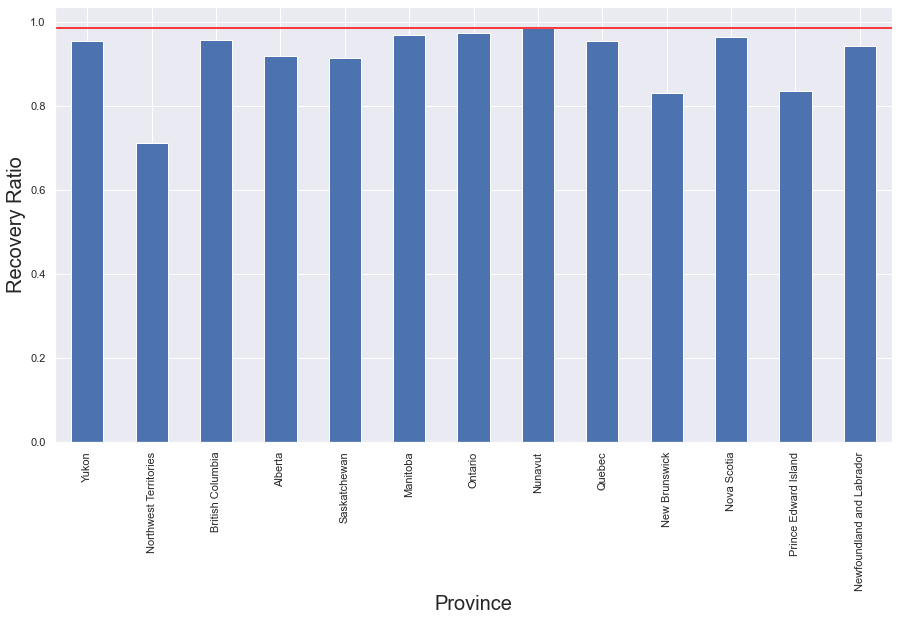

```python
province['recovery_rate'].plot(kind='bar')
plt.xlabel('Province',fontsize=20)
plt.ylabel('Recovery Ratio', fontsize=20)
#allows me to clearly see the province with the highest rate
plt.axhline(y=province.recovery_rate.max(),
            color='red')
```

As you can see in the graph many of the provinces have similar recovery rates. Because of this I drew a red line in order to decifer which one had the highest. Nunavut has the highest recovery rate, almost close to 1.

### Q8 Create visualizations that show the effects of _at least_ three policy measures.

See https://covid19datahub.io/articles/doc/data.html for descriptions of the available policy measures. You are not limited to histograms and bar charts. Remember that you can use subplots!

```python
travel_policy = covid_data.groupby('international_movement_restrictions').sum().reset_index()
travel_policy.head()
#here I realized that the tests were cumulative so I would need to go back and sum based on the tests per day
#because I dont want to count tests during other policy times
```

|  | international_movement_restrictions | vaccines | tests | confirmed | recovered | deaths | hosp | vent | icu | population | ... | testing_policy | contact_tracing | stringency_index | iso_numeric | administrative_area_level | administrative_area_level_2 | administrative_area_level_3 | latitude | longitude | key |
| --- | --- | --- | --- | --- | --- | --- | --- | --- | --- | --- | --- | --- | --- | --- | --- | --- | --- | --- | --- | --- | --- |
| 0 | 0.0 | 1.334969e+08 | 2.701629e+08 | 5.488583e+07 | 2.451262e+07 | 3454721.0 | 1000894.00 | 125925.0 | 129050.0 | 231870580316 | ... | 3083.0 | 2771.0 | 69995.34 | 2858352.0 | 6507 | 0.0 | 0.0 | 142906.346026 | 5.584468e+04 | 0.0 |
| 1 | 1.0 | 3.790878e+10 | 3.657394e+10 | 8.323254e+09 | 6.617469e+09 | 260533441.0 | 301887.00 | 3055.0 | 35014.0 | 570543919138 | ... | 34590.0 | 22542.0 | 808468.67 | 7478484.0 | 18479 | 0.0 | 0.0 | 255745.720442 | 1.989140e+04 | 0.0 |
| 2 | 2.0 | 4.032442e+10 | 5.570118e+10 | 4.843239e+09 | 2.845812e+09 | 107407104.0 | 6776988.00 | 325481.0 | 698806.0 | 669884742097 | ... | 46335.0 | 32727.0 | 1158977.11 | 9623603.0 | 22725 | 0.0 | 0.0 | 469570.217987 | 4.742333e+05 | 0.0 |
| 3 | 3.0 | 1.849902e+11 | 3.884819e+11 | 2.973140e+10 | 1.365472e+10 | 603969275.0 | 59739074.00 | 858169.0 | 12226938.0 | 2194716323496 | ... | 68437.0 | 45535.0 | 1895863.66 | 14045612.0 | 32883 | 0.0 | 0.0 | 953570.948689 | 1.007176e+06 | 0.0 |
| 4 | 4.0 | 2.606714e+10 | 4.515398e+10 | 3.759477e+09 | 2.793028e+09 | 83517186.0 | 22142020.93 | 306547.0 | 1538179.0 | 898220196016 | ... | 46287.0 | 37022.0 | 1817248.15 | 10470715.0 | 26245 | 0.0 | 0.0 | 272129.260324 | 7.582556e+05 | 0.0 |

5 rows × 28 columns

```python
#made a copy of data to keep a true source
international_travel = covid_data.copy(deep = True)

#got the individual tests per day so it's not cumulative and I can then sum on the policy measure
international_travel['tests_per_day'] = international_travel['tests'].diff()
travel_policy = international_travel.groupby('international_movement_restrictions').sum().reset_index()
travel_policy
```

|  | international_movement_restrictions | vaccines | tests | confirmed | recovered | deaths | hosp | vent | icu | population | ... | contact_tracing | stringency_index | iso_numeric | administrative_area_level | administrative_area_level_2 | administrative_area_level_3 | latitude | longitude | key | tests_per_day |
| --- | --- | --- | --- | --- | --- | --- | --- | --- | --- | --- | --- | --- | --- | --- | --- | --- | --- | --- | --- | --- | --- |
| 0 | 0.0 | 1.334969e+08 | 2.701629e+08 | 5.488583e+07 | 2.451262e+07 | 3454721.0 | 1000894.00 | 125925.0 | 129050.0 | 231870580316 | ... | 2771.0 | 69995.34 | 2858352.0 | 6507 | 0.0 | 0.0 | 142906.346026 | 5.584468e+04 | 0.0 | 6.977998e+06 |
| 1 | 1.0 | 3.790878e+10 | 3.657394e+10 | 8.323254e+09 | 6.617469e+09 | 260533441.0 | 301887.00 | 3055.0 | 35014.0 | 570543919138 | ... | 22542.0 | 808468.67 | 7478484.0 | 18479 | 0.0 | 0.0 | 255745.720442 | 1.989140e+04 | 0.0 | 1.509163e+08 |
| 2 | 2.0 | 4.032442e+10 | 5.570118e+10 | 4.843239e+09 | 2.845812e+09 | 107407104.0 | 6776988.00 | 325481.0 | 698806.0 | 669884742097 | ... | 32727.0 | 1158977.11 | 9623603.0 | 22725 | 0.0 | 0.0 | 469570.217987 | 4.742333e+05 | 0.0 | 2.758158e+08 |
| 3 | 3.0 | 1.849902e+11 | 3.884819e+11 | 2.973140e+10 | 1.365472e+10 | 603969275.0 | 59739074.00 | 858169.0 | 12226938.0 | 2194716323496 | ... | 45535.0 | 1895863.66 | 14045612.0 | 32883 | 0.0 | 0.0 | 953570.948689 | 1.007176e+06 | 0.0 | 1.814535e+09 |
| 4 | 4.0 | 2.606714e+10 | 4.515398e+10 | 3.759477e+09 | 2.793028e+09 | 83517186.0 | 22142020.93 | 306547.0 | 1538179.0 | 898220196016 | ... | 37022.0 | 1817248.15 | 10470715.0 | 26245 | 0.0 | 0.0 | 272129.260324 | 7.582556e+05 | 0.0 | 3.589166e+08 |

5 rows × 29 columns

[output not shown]

[figure not shown]

```python
travel_policy.plot(x="international_movement_restrictions", y=["hosp", "tests_per_day"], kind="bar")
plt.xlabel("International Policy Measure",fontsize=20)
plt.ylabel("Count 1e9",fontsize=20)
plt.title('Tests by Provice per 1,000 People', fontsize=20)
plt.xticks(rotation =45)
ax = plt.axes()
ax.set_xticklabels(['No measures', 'Screenings', 'Quarantine arrivals from high-risk regions', 'Ban on high-risk regions','Total border closure'])
```

Here we can see the tests during certain times when international policy measures are in place. From the graph I notice that when policies get more serious such as the ban on high-risk regions, the tests increase. One hypothesis of my own, not proven by the data, could be that people are starting to be more cautious and taking more action to get tested. Another trend shown is a decrease in hospitalizations once the international policy measures are the most strict.

```python
campaigns = covid_data.copy(deep = True)
#gets the vaccines given per day
campaigns['vaccines_per_day'] = campaigns['vaccines'].diff()
campaigns = campaigns[['vaccines_per_day','date','information_campaigns']]

#dropped the dates filled with NA vaccines per day and when information campaigns was NA in order to only
#look at the affect when campaigns were noted and vaccines started to get distributed
campaigns = campaigns[campaigns['vaccines_per_day'].notna()]
campaigns = campaigns[campaigns['information_campaigns'].notna()]
campaigns
```

|  | vaccines_per_day | date | information_campaigns |
| --- | --- | --- | --- |
| 491 | 2859.0 | 2021-05-27 | 1.0 |
| 498 | 4015.0 | 2021-06-03 | 1.0 |
| 1577 | 60.0 | 2021-01-13 | 2.0 |
| 1578 | 78.0 | 2021-01-14 | 2.0 |
| 1579 | 42.0 | 2021-01-15 | 2.0 |
| ... | ... | ... | ... |
| 122579 | 59133.0 | 2021-09-08 | 2.0 |
| 122580 | 48944.0 | 2021-09-09 | 2.0 |
| 122581 | 54428.0 | 2021-09-10 | 2.0 |
| 122582 | 52457.0 | 2021-09-11 | 2.0 |
| 122585 | 48405.0 | 2021-09-14 | 2.0 |

17790 rows × 3 columns

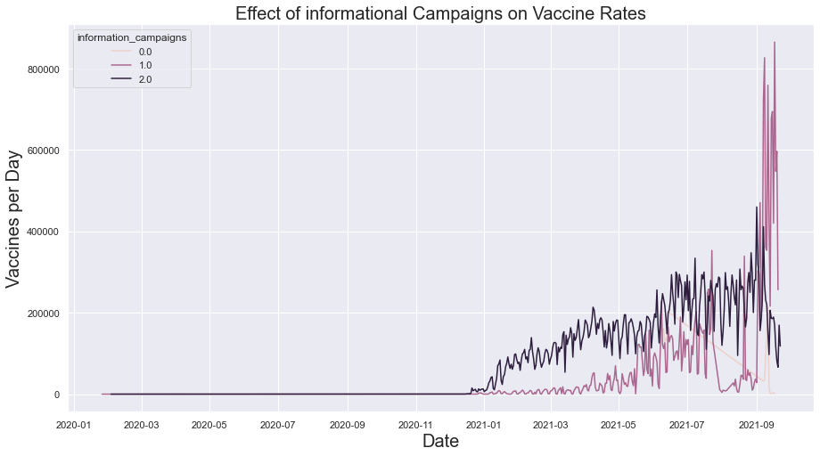

```python
sns.lineplot(data = campaigns, x = 'date', y = 'vaccines_per_day', hue = 'information_campaigns', ci=None)
plt.xlabel("Date",fontsize=20)
plt.ylabel("Vaccines per Day",fontsize=20)
plt.title('Effect of informational Campaigns on Vaccine Rates', fontsize=20)
```

0: No COVID-19 public information campaign - 1: public officials urging caution about COVID-19 - 2: coordinated public information campaign

I wanted to analyze if information campaigns played an affect on vaccine distributed. Initially when we did not know very much about COVID there was no vaccines or campaigns. As we continue to analyze, we can see that when covid started getting bad around 2021-01 areas who had coordinated public information given recieved more vaccines than those in areas where people just urged about COVID or did nothing at all. At the end of the graph you can start to see the affect these campaigns had dwindle down a little as the rates for urging and coordinating start to become more similar. Interstingly at the end there is a huge spike, much larger than the other categories, in when public officials simply urge.

```python
gatherings_restrictions = us_covid.copy(deep = True)
gatherings_restrictions['deaths_per_day'] = gatherings_restrictions['deaths'].diff()

gatherings_restrictions = gatherings_restrictions.groupby('gatherings_restrictions').sum().reset_index()
gatherings_restrictions['deaths_to_confirmed'] = (gatherings_restrictions.deaths_per_day / gatherings_restrictions.confirmed_per_day)
gatherings_restrictions
```

|  | gatherings_restrictions | vaccines | tests | confirmed | recovered | deaths | hosp | vent | icu | population | ... | iso_numeric | administrative_area_level | administrative_area_level_2 | administrative_area_level_3 | latitude | longitude | key | confirmed_per_day | deaths_per_day | deaths_to_confirmed |
| --- | --- | --- | --- | --- | --- | --- | --- | --- | --- | --- | --- | --- | --- | --- | --- | --- | --- | --- | --- | --- | --- |
| 0 | 0.0 | 0.000000e+00 | 5.432600e+04 | 3.430000e+03 | 159.0 | 140.0 | 0.0 | 0.0 | 0.0 | 16007687549 | ... | 41160.0 | 49 | 0.0 | 0.0 | 1862.0 | -4753.0 | 0.0 | 781.0 | 27.0 | 0.034571 |
| 1 | 1.0 | 0.000000e+00 | 1.918300e+04 | 1.147000e+03 | 8.0 | 33.0 | 0.0 | 0.0 | 0.0 | 326687501 | ... | 840.0 | 1 | 0.0 | 0.0 | 38.0 | -97.0 | 0.0 | 365.0 | 5.0 | 0.013699 |
| 2 | 2.0 | 0.000000e+00 | 1.167422e+06 | 6.404800e+04 | 455.0 | 1285.0 | 0.0 | 0.0 | 0.0 | 2940187509 | ... | 7560.0 | 9 | 0.0 | 0.0 | 342.0 | -873.0 | 0.0 | 18883.0 | 339.0 | 0.017953 |
| 3 | 3.0 | 1.126892e+10 | 2.491091e+10 | 1.676980e+09 | 207925889.0 | 34360897.0 | 3638026.0 | 0.0 | 978938.0 | 32015375098 | ... | 82320.0 | 98 | 0.0 | 0.0 | 3724.0 | -9506.0 | 0.0 | 6900175.0 | 65904.0 | 0.009551 |
| 4 | 4.0 | 4.586618e+10 | 1.089539e+11 | 8.522987e+09 | 289045317.0 | 160472678.0 | 19879819.0 | 0.0 | 5052213.0 | 147662750452 | ... | 379680.0 | 452 | 0.0 | 0.0 | 17176.0 | -43844.0 | 0.0 | 35490402.0 | 612131.0 | 0.017248 |

5 rows × 31 columns

[output not shown]

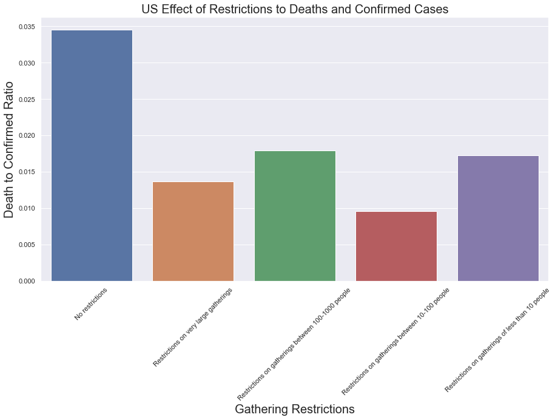

```python
sns.barplot(x='gatherings_restrictions', y='deaths_to_confirmed', data = gatherings_restrictions)
plt.xlabel("Gathering Restrictions",fontsize=20)
plt.ylabel("Death to Confirmed Ratio",fontsize=20)
plt.title('US Effect of Restrictions to Deaths and Confirmed Cases', fontsize=20)
ax = plt.axes()
plt.xticks(rotation =45)
ax.set_xticklabels(['No restrictions', 'Restrictions on very large gatherings', 'Restrictions on gatherings between 100-1000 people', 'Restrictions on gatherings between 10-100 people','Restrictions on gatherings of less than 10 people'])
```

```python
#here I get the US population that way I can compare the ratio of deaths to people
us_population = us_covid.groupby(['gatherings_restrictions']).agg({'population' : 'max'})
df = pd.merge(us_population, gatherings_restrictions, on='gatherings_restrictions')
df['deaths_to_pop'] = (df.deaths_per_day / df.population_x)
df.head()
```

|  | gatherings_restrictions | population_x | vaccines | tests | confirmed | recovered | deaths | hosp | vent | icu | ... | administrative_area_level | administrative_area_level_2 | administrative_area_level_3 | latitude | longitude | key | confirmed_per_day | deaths_per_day | deaths_to_confirmed | deaths_to_pop |
| --- | --- | --- | --- | --- | --- | --- | --- | --- | --- | --- | --- | --- | --- | --- | --- | --- | --- | --- | --- | --- | --- |
| 0 | 0.0 | 326687501 | 0.000000e+00 | 5.432600e+04 | 3.430000e+03 | 159.0 | 140.0 | 0.0 | 0.0 | 0.0 | ... | 49 | 0.0 | 0.0 | 1862.0 | -4753.0 | 0.0 | 781.0 | 27.0 | 0.034571 | 8.264779e-08 |
| 1 | 1.0 | 326687501 | 0.000000e+00 | 1.918300e+04 | 1.147000e+03 | 8.0 | 33.0 | 0.0 | 0.0 | 0.0 | ... | 1 | 0.0 | 0.0 | 38.0 | -97.0 | 0.0 | 365.0 | 5.0 | 0.013699 | 1.530515e-08 |
| 2 | 2.0 | 326687501 | 0.000000e+00 | 1.167422e+06 | 6.404800e+04 | 455.0 | 1285.0 | 0.0 | 0.0 | 0.0 | ... | 9 | 0.0 | 0.0 | 342.0 | -873.0 | 0.0 | 18883.0 | 339.0 | 0.017953 | 1.037689e-06 |
| 3 | 3.0 | 326687501 | 1.126892e+10 | 2.491091e+10 | 1.676980e+09 | 207925889.0 | 34360897.0 | 3638026.0 | 0.0 | 978938.0 | ... | 98 | 0.0 | 0.0 | 3724.0 | -9506.0 | 0.0 | 6900175.0 | 65904.0 | 0.009551 | 2.017341e-04 |
| 4 | 4.0 | 326687501 | 4.586618e+10 | 1.089539e+11 | 8.522987e+09 | 289045317.0 | 160472678.0 | 19879819.0 | 0.0 | 5052213.0 | ... | 452 | 0.0 | 0.0 | 17176.0 | -43844.0 | 0.0 | 35490402.0 | 612131.0 | 0.017248 | 1.873751e-03 |

5 rows × 33 columns

[output not shown]

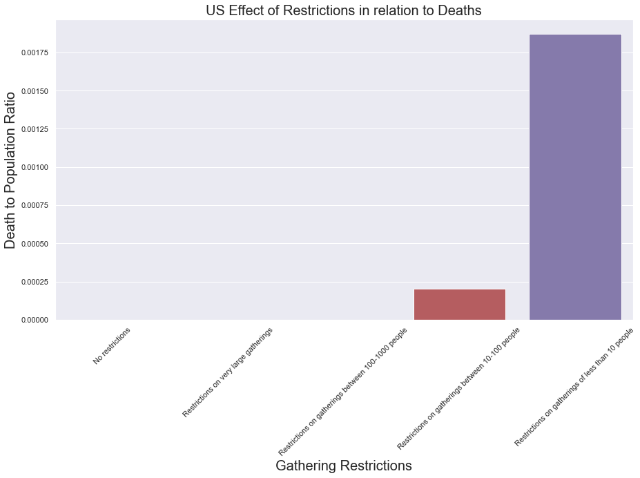

```python
sns.barplot(x='gatherings_restrictions', y='deaths_to_pop', data = df)
plt.xlabel("Gathering Restrictions",fontsize=20)
plt.ylabel("Death to Population Ratio",fontsize=20)
plt.title('US Effect of Restrictions in relation to Deaths', fontsize=20)
ax = plt.axes()
plt.xticks(rotation =45)
ax.set_xticklabels(['No restrictions', 'Restrictions on very large gatherings', 'Restrictions on gatherings between 100-1000 people', 'Restrictions on gatherings between 10-100 people','Restrictions on gatherings of less than 10 people'])
```

In these two graphs I wanted to first narrow down on US data. The policy I chose to look at was the one regarding gatherings. In the first graph I compared the deaths to confirmed cases ratios during all of the phases of restricted gatherings. Here we can see there is not a trend showing that stricter polices lead to less deaths. To further analyze this I created a second graph showing the death to overall population ratios. Interesting the tighest resriction is shown to have the highest ratio. *Disclaimer* These two sets are not enough to come to any overarching conclusions regarding the effectivenss of these restrictions because of other factors that can affect rates, ratios, and data as a whole as well.

## Please submit your completed notebook in .IPYNB and .HTML formats via Canvas